# itsjon_OriginalHomeworkCode_03

Jonathan Zhang

2025-02-26

## Libraries

```r
library(tidyverse)
```

```r
library(ggplot2)
library(readr)
```

# Dataset

```r
zombie_data <- read_csv("C:/Users/Richard/Desktop/AN588 R Studio/Homework 3/zombies.csv")
head(zombie_data)
```

```
## # A tibble: 6 × 10
##      id first_name last_name gender height weight zombies_killed
##   <dbl> <chr>      <chr>     <chr>   <dbl>  <dbl>          <dbl>
## 1     1 Sarah      Little    Female   62.9   132.              2
## 2     2 Mark       Duncan    Male     67.8   146.              5
## 3     3 Brandon    Perez     Male     72.1   153.              1
## 4     4 Roger      Coleman   Male     66.8   130.              5
## 5     5 Tammy      Powell    Female   64.7   132.              4
## 6     6 Anthony    Green     Male     71.2   153.              1
## # ℹ 3 more variables: years_of_education <dbl>, major <chr>, age <dbl>
```

```r
zombie_data
```

```
## # A tibble: 1,000 × 10
##       id first_name last_name gender    height weight zombies_killed
##    <dbl> <chr>      <chr>     <chr>      <dbl>  <dbl>          <dbl>
##  1     1 Sarah      Little    Female      62.9   132.              2
##  2     2 Mark       Duncan    Male        67.8   146.              5
##  3     3 Brandon    Perez     Male        72.1   153.              1
##  4     4 Roger      Coleman   Male        66.8   130.              5
##  5     5 Tammy      Powell    Female      64.7   132.              4
##  6     6 Anthony    Green     Male        71.2   153.              1
##  7     7 Theresa    Hamilton  Female      70.3   160.              0
##  8     8 Phyllis    Jenkins   Female      59.8   109.              4
##  9     9 Sage       Long      NonBinary   68.6   153.              9
## 10    10 Russell    Chavez    Male        72.8   169.              2
## # ℹ 990 more rows
## # ℹ 3 more variables: years_of_education <dbl>, major <chr>, age <dbl>
```

# Question 1

Calculate the population mean and standard deviation for each quantitative random variable (height, weight, age, number of zombies killed, and years of education). NOTE: You will not want to use the built in var() and sd() commands as these are for samples.

```r
pop_means <- zombie_data %>%
summarise(
    mean_height = mean(height),
    sd_height = sqrt(mean((height - mean(height))^2)),
    mean_weight = mean(weight),
    sd_weight = sqrt(mean((weight - mean(weight))^2)),
    mean_age = mean(age),
    sd_age = sqrt(mean((age - mean(age))^2)),
    mean_zombies_killed = mean(zombies_killed),
    sd_zombies_killed = sqrt(mean((zombies_killed - mean(zombies_killed))^2)),
    mean_education = mean(years_of_education),
    sd_education = sqrt(mean((years_of_education - mean(years_of_education))^2))
)
pop_means
```

```
## # A tibble: 1 × 10
##   mean_height sd_height mean_weight sd_weight mean_age sd_age
##         <dbl>     <dbl>       <dbl>     <dbl>    <dbl>  <dbl>
## 1        67.6      4.31        144.      18.4     20.0   2.96
## # ℹ 4 more variables: mean_zombies_killed <dbl>, sd_zombies_killed <dbl>,
## #   mean_education <dbl>, sd_education <dbl>
```

# Question 2

Use {ggplot} to make boxplots of each of these variables by gender.

```r
boxplot_vars <- c("height", "weight", "age", "zombies_killed", "years_of_education")

for (var in boxplot_vars) {
"Height"
g1 <- ggplot(zombie_data, aes(x = gender, y = height, fill = gender)) +
    geom_boxplot() +
    labs(title = paste("Boxplot of Height by Gender"), y = "height") +
    theme_minimal() +
    theme(legend.position = "none")
"Weight"
g2 <- ggplot(zombie_data, aes(x = gender, y = weight, fill = gender)) +
    geom_boxplot() +
    labs(title = paste("Boxplot of Weight by Gender"), y = "weights") +
    theme_minimal() +
    theme(legend.position = "none")
"Age"
g3 <- ggplot(zombie_data, aes(x = gender, y = age, fill = gender)) +
    geom_boxplot() +
    labs(title = paste("Boxplot of Age by Gender"), y = "age") +
    theme_minimal() +
    theme(legend.position = "none")
"zombies_killed"
g4 <- ggplot(zombie_data, aes(x = gender, y = zombies_killed, fill = gender)) +
    geom_boxplot() +
    labs(title = paste("Boxplot of Kill Rates by Gender"), y = "zombies_killed") +
    theme_minimal() +
    theme(legend.position = "none")
"years_of_education"
g5 <- ggplot(zombie_data, aes(x = gender, y = years_of_education, fill = gender)) +
    geom_boxplot() +
    labs(title = paste("Boxplot of Education by Gender"), y = "years_of_education") +
    theme_minimal() +
    theme(legend.position = "none")
}
```

# Question 3

Using histograms and Q-Q plots, check whether the quantitative variables seem to be drawn from a normal distribution. Which seem to be and which do not (hint: not all are drawn from the normal distribution)? For those that are not normal, can you determine from which common distribution they are drawn?

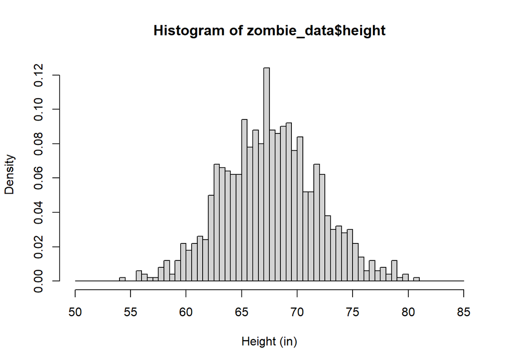

```r
quant_vars <- c("height", "weight", "age", "zombies_killed", "years_of_education")

# height
hist(zombie_data$height, breaks = seq(from = 50, to = 85, by = .5), xlab = "Height (in)", probability = TRUE)
```

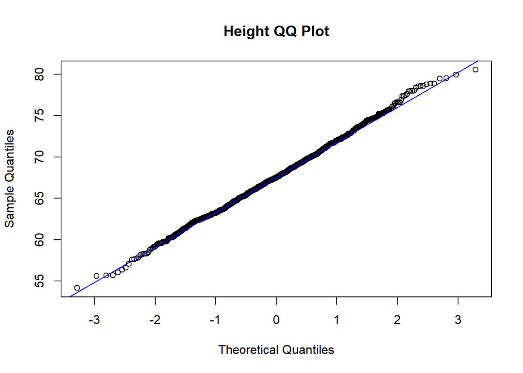

```r
qqnorm(zombie_data$height, main = "Height QQ Plot")
qqline(zombie_data$height, col = "blue")
```

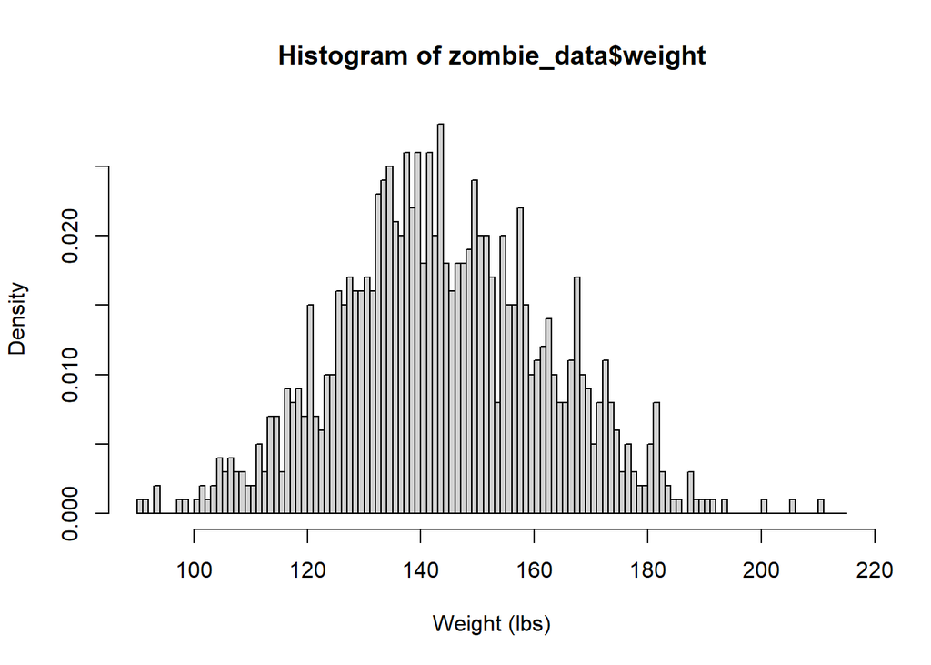

```r
# weight
hist(zombie_data$weight, breaks = seq(from = 90, to = 215, by = 1), xlab = "Weight (lbs)", probability = TRUE)
```

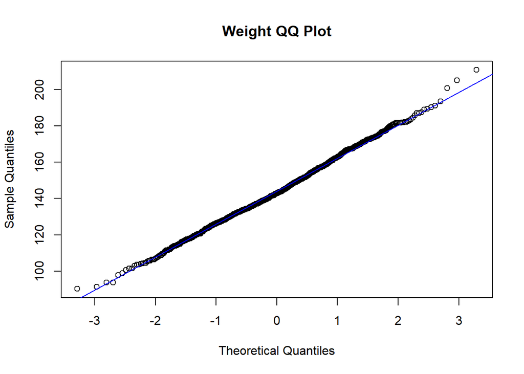

```r
qqnorm(zombie_data$weight, main = "Weight QQ Plot")
qqline(zombie_data$weight, col = "blue")
```

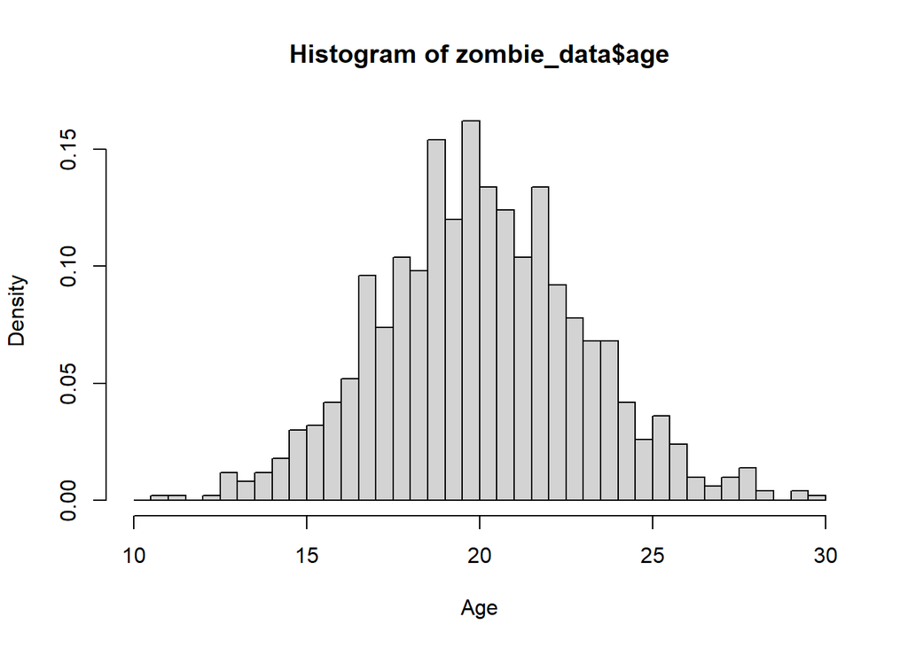

```r
# age
hist(zombie_data$age, breaks = seq(from = 10, to = 30, by = 0.5), xlab = "Age", probability = TRUE)
```

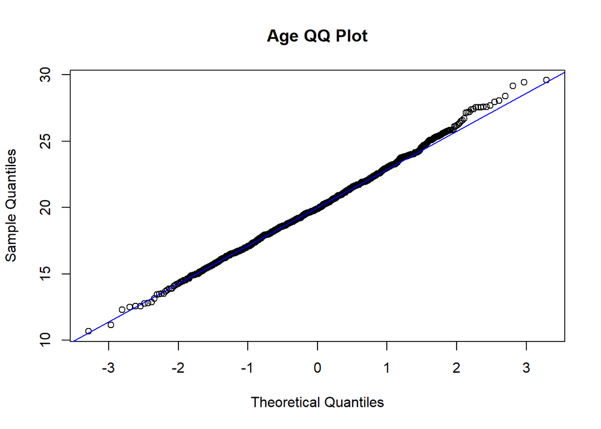

```r
qqnorm(zombie_data$age, main = "Age QQ Plot")
qqline(zombie_data$age, col = "blue")
```

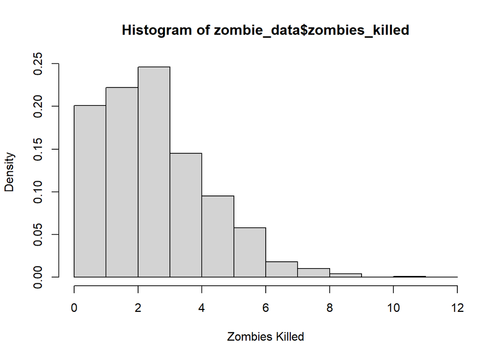

```r
# zombie kills
hist(zombie_data$zombies_killed, breaks = seq(from = 0, to = 12, by = 1), xlab = "Zombies Killed", probability = TRUE)
```

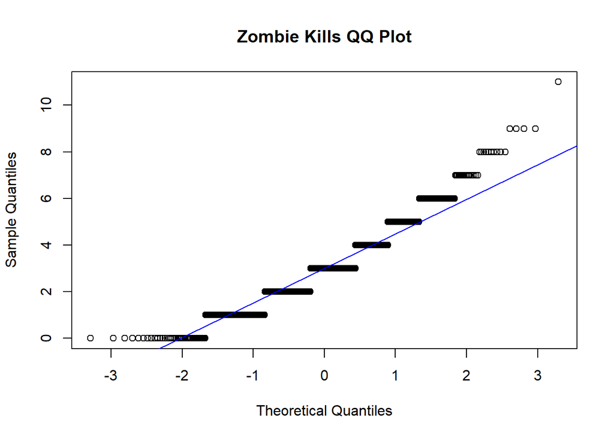

```r
qqnorm(zombie_data$zombies_killed, main = "Zombie Kills QQ Plot")
qqline(zombie_data$zombies_killed, col = "blue")
```

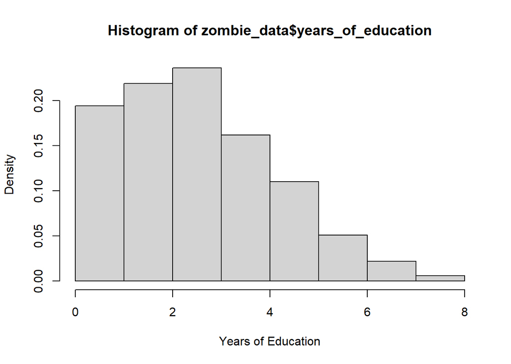

```r
# years of education
hist(zombie_data$years_of_education, breaks = seq(from = 0, to = 8, by = 1), xlab = "Years of Education", probability = TRUE)
```

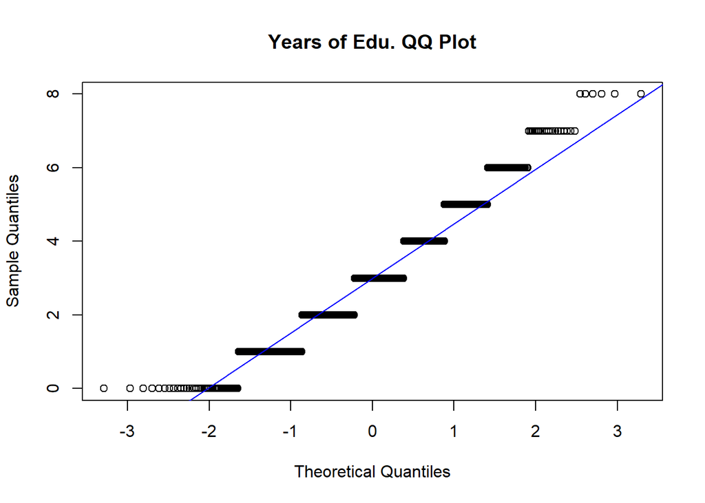

```r
qqnorm(zombie_data$years_of_education, main = "Years of Edu. QQ Plot")
qqline(zombie_data$years_of_education, col = "blue")
```

Which seem to be and which do not (hint: not all are drawn from the normal distribution)?

> Both Zombies Killed and Years of Education seem to be the only variables that are not drawn from the normal distribution.

For those that are not normal, can you determine from which common distribution they are drawn?

> Both are count data, so I think they draw from a Poisson distribution.

# Question 5

Now use the sample() function to sample ONE subset of 30 zombie survivors (without replacement) from this population and calculate the mean and sample standard deviation for each variable. Also estimate the standard error for each variable, and construct the 95% confidence interval for each mean.

```r
sample_30 <- zombie_data %>% sample_n(30)

# Mean and Standard Deviation
sample_stats <- sample_30 %>%
  summarise(
    mean_height = mean(height),
    sd_height = sd(height),
    se_height = sd(height) / sqrt(n()),

    mean_weight = mean(weight),
    sd_weight = sd(weight),
    se_weight = sd(weight) / sqrt(n()),

    mean_age = mean(age),
    sd_age = sd(age),
    se_age = sd(age) / sqrt(n()),

    mean_zombies_killed = mean(zombies_killed),
    sd_zombies_killed = sd(zombies_killed),
    se_zombies_killed = sd(zombies_killed) / sqrt(n()),

    mean_education = mean(years_of_education),
    sd_education = sd(years_of_education),
    se_education = sd(years_of_education) / sqrt(n())
  )

# 95% Confidence Interval Calculation
sample_stats <- sample_stats %>%
  mutate(
    ci_low_height = mean_height - 1.96 * se_height,
    ci_high_height = mean_height + 1.96 * se_height,

    ci_low_weight = mean_weight - 1.96 * se_weight,
    ci_high_weight = mean_weight + 1.96 * se_weight,

    ci_low_age = mean_age - 1.96 * se_age,
    ci_high_age = mean_age + 1.96 * se_age,

    ci_low_zombies_killed = mean_zombies_killed - 1.96 * se_zombies_killed,
    ci_high_zombies_killed = mean_zombies_killed + 1.96 * se_zombies_killed,

    ci_low_education = mean_education - 1.96 * se_education,
    ci_high_education = mean_education + 1.96 * se_education
  )

sample_stats
```

```
## # A tibble: 1 × 25
##   mean_height sd_height se_height mean_weight sd_weight se_weight mean_age
##         <dbl>     <dbl>     <dbl>       <dbl>     <dbl>     <dbl>    <dbl>
## 1        68.4      4.23     0.773        149.      18.3      3.35     19.7
## # ℹ 18 more variables: sd_age <dbl>, se_age <dbl>, mean_zombies_killed <dbl>,
## #   sd_zombies_killed <dbl>, se_zombies_killed <dbl>, mean_education <dbl>,
## #   sd_education <dbl>, se_education <dbl>, ci_low_height <dbl>,
## #   ci_high_height <dbl>, ci_low_weight <dbl>, ci_high_weight <dbl>,
## #   ci_low_age <dbl>, ci_high_age <dbl>, ci_low_zombies_killed <dbl>,
## #   ci_high_zombies_killed <dbl>, ci_low_education <dbl>,
## #   ci_high_education <dbl>
```

# Question 6

Now draw 99 more random samples of 30 zombie apocalypse survivors, and calculate the mean for each variable for each of these samples. Together with the first sample you drew, you now have a set of 100 means for each variable (each based on 30 observations), which constitutes a sampling distribution for each variable. What are the means and standard deviations of this distribution of means for each variable? How do the standard deviations of means compare to the standard errors estimated in [5]? What do these sampling distributions look like (a graph might help here)? Are they normally distributed? What about for those variables that you concluded were not originally drawn from a normal distribution? > Jon’s Notes: “I got stuck when trying to contruct the graph, so I wasn’t able to finish it.”

```r
# 6. Generate 99 more samples and compute means for each

num_samples <- 100  # Total number of samples
sample_size <- 30   # Each sample contains 30 survivors

# Create an empty data frame to store sample means
sampling_dist <- data.frame(matrix(ncol = length(quant_vars), nrow = num_samples))
colnames(sampling_dist) <- paste0(quant_vars, "_mean")

# Generate 100 random samples and compute means for each
for (i in 1:num_samples) {
  sample_i <- zombie_data %>% sample_n(sample_size)
  sampling_dist[i, ] <- sample_i %>%
    summarise(across(all_of(quant_vars), mean)) %>%
    unlist()  # Convert to vector for proper insertion
}

# Check the first few rows of the sampling distribution
print(head(sampling_dist))
```

```
##   height_mean weight_mean age_mean zombies_killed_mean years_of_education_mean
## 1    67.88213    141.4901 19.55027            2.733333                3.066667
## 2    67.31610    141.5026 20.32949            3.300000                2.833333
## 3    66.73592    142.8778 19.58178            2.966667                2.766667
## 4    68.17380    142.6178 21.08330            3.400000                2.800000
## 5    66.85116    143.5179 19.55686            3.133333                3.133333
## 6    67.19726    141.7074 19.69896            2.666667                2.966667
```

```r
# Compute mean and standard deviation of the sampling distribution
sampling_summary <- sampling_dist %>%
  summarise(across(everything(), list(mean = mean, sd = sd), .names = "{.col}_{.fn}"))

print(sampling_summary)  # Check structure
```

```
##   height_mean_mean height_mean_sd weight_mean_mean weight_mean_sd age_mean_mean
## 1          67.7077      0.8801363          144.292       3.579368      20.02615
##   age_mean_sd zombies_killed_mean_mean zombies_killed_mean_sd
## 1   0.5887839                    2.974              0.2941853
##   years_of_education_mean_mean years_of_education_mean_sd
## 1                        2.984                   0.256519
```

```r
# Ensure sample_stats is correctly structured
sample_stats <- sample_30 %>%
  summarise(across(all_of(quant_vars), list(
    mean = mean,
    sd = sd,
    se = ~ sd(.) / sqrt(n())  # Standard Error
  ), .names = "{.col}_{.fn}"))

print(sample_stats)  # Debugging check
```

```
## # A tibble: 1 × 15
##   height_mean height_sd height_se weight_mean weight_sd weight_se age_mean
##         <dbl>     <dbl>     <dbl>       <dbl>     <dbl>     <dbl>    <dbl>
## 1        68.4      4.23     0.773        149.      18.3      3.35     19.7
## # ℹ 8 more variables: age_sd <dbl>, age_se <dbl>, zombies_killed_mean <dbl>,
## #   zombies_killed_sd <dbl>, zombies_killed_se <dbl>,
## #   years_of_education_mean <dbl>, years_of_education_sd <dbl>,
## #   years_of_education_se <dbl>
```

```r
# Construct comparison table
comparison <- data.frame(
  variable = quant_vars,  # Variable names
  estimated_se = as.numeric(sample_stats %>% select(ends_with("_se"))),  # SE from sample
  sd_of_means = as.numeric(sampling_summary %>% select(ends_with("_sd")))  # SD of sampling means
)
comparison
```

```
##             variable estimated_se sd_of_means
## 1             height    0.7729979   0.8801363
## 2             weight    3.3478316   3.5793685
## 3                age    0.5717555   0.5887839
## 4     zombies_killed    0.3299251   0.2941853
## 5 years_of_education    0.3579957   0.2565190
```